# Data Science for Public Policy

Assignment 04

Author

Duana - db1605 and Jasmine - jj1073

### Source

World Bank Development Indicators

https://databank.worldbank.org/source/world-development-indicators#

```r
library (tidyverse)
library (haven)
library (readxl)

data <- read_excel('C:\\Users\\duana\\OneDrive\\McCourt_MIDP\\Sem2\\IntroDataScience\\assignment04\\Assignment04\\assignment04\\data\\assignment4.xlsx')

library(ggthemes)
library(ggplot2)
```

# Data Visualization

### Graph 1 - Relationship between GDP Per Capita and Infant Mortality Rate in India (2000-2019)

#### From 2000 to 2019, as GDP per capita increased in India, we noticed that the infant mortality rate fell, on average. This relationship is close to a perfect negative one. This graph does not imply a causal relationship. We can only see an association between the two indicators. The reason behind it may be associated with the fact that an increase in GDP per capita could have led India to invest more in health initiatives, generating a decrease in infant mortality.

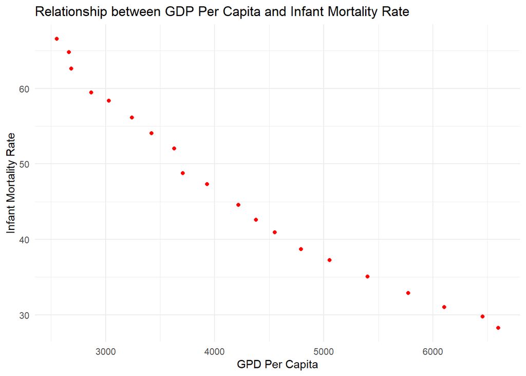

```r
data %>%
ggplot(mapping = aes(x = GDP_pp, y = mortality_rate_infant)) +
  geom_jitter(color = "red") +
  theme_minimal()+
  labs(title = 'Relationship between GDP Per Capita and Infant Mortality Rate',
       x = 'GPD Per Capita', y = 'Infant Mortality Rate')
```

### Graph 2 - Trend of Life Expectancy at Birth (2000-2019)

#### From 2000 to 2019, the life expectancy at birth in India has increased. The growth is consistent with Graph 1 (above), indicating a possible increase in health investments. In less than 20 years, the life expectancy increases from 62.67 years old to 70.91 years old.

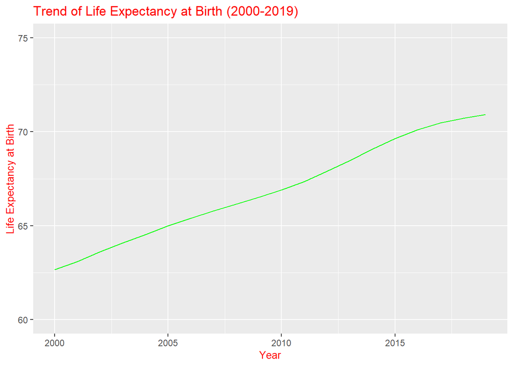

```r
data %>%
  ggplot(mapping = aes(x = year, y = life_expectancy_at_birth)) +
  geom_path(color = "green") +
  labs(title = 'Trend of Life Expectancy at Birth (2000-2019)',
       x = 'Year', y = 'Life Expectancy at Birth') +
  theme(plot.title = element_text(color = "red"),
          axis.title.x = element_text(color = "red", size = 10),
    axis.title.y = element_text(color = "red", size = 10)) +
  guides(color = guide_legend(title = 'Trend of Life Expectancy at Birth (2000-2019)')) +
  scale_y_continuous(limits = c(60, 75))
```

### Graph 3 - Trend of Fertility Rate (2000-2019)

#### From 2000 to 2019, the fertility rate per woman, in India has decreased on average. That means that women in general have been having less children. This can be a sign of social and economic development. In Graph 1 we saw that the GDP per capita is increeasing on the same period. We can notice a sign of a demographic transition - where the birthrate falls.

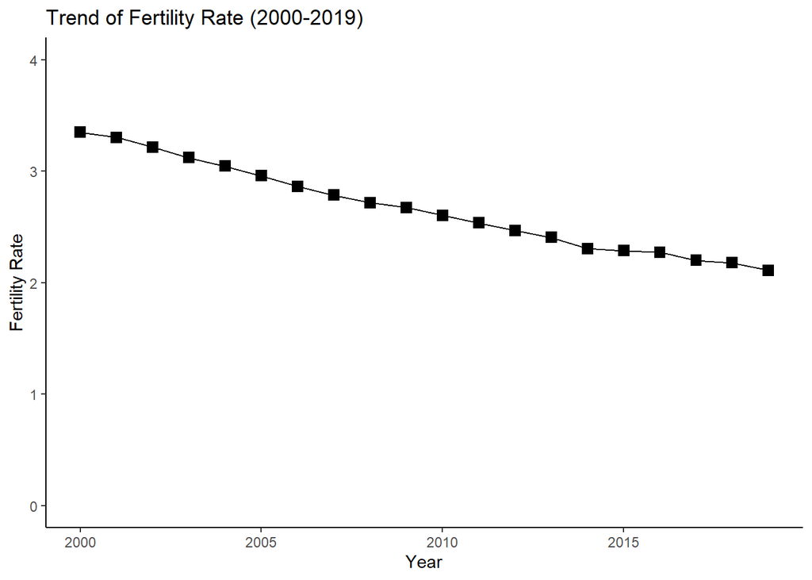

```r
data %>%
  distinct(fertility_rate, year) %>%
  ggplot() +
  geom_line(mapping = aes(x = year, y = fertility_rate)) +
  geom_point(mapping = aes(x = year, y = fertility_rate), size = 3, shape = 15) +
  labs(title = 'Trend of Fertility Rate (2000-2019)',
       x = 'Year', y = 'Fertility Rate') +
  scale_y_continuous(limits = c(0, 4)) +
  theme_classic()
```

### Graph 4 - Life expectancy comparison between male and female (2000-2019)

#### From 2000 to 2019, on average, women’s and men’s life expectancy has been increasing in India. We could also see this result in Graph 2. However, comparing the two groups, we noticed that women have a higher life expectancy at birth than men. This difference is consistent throughout the years. This result is consistent with a universal trend that women live more than men.

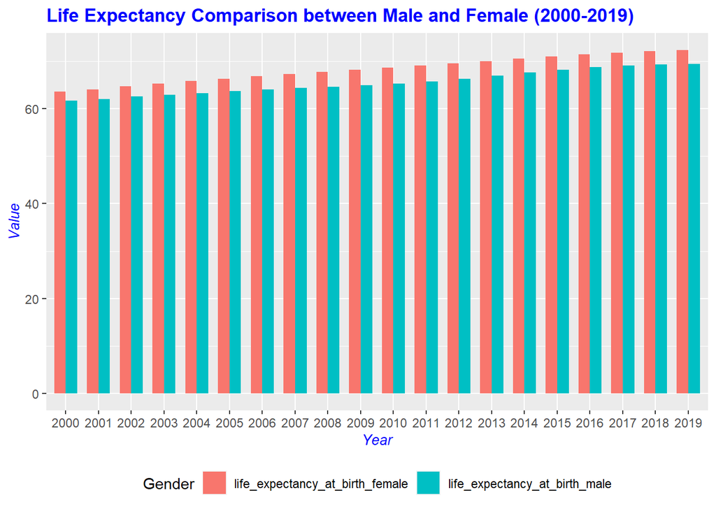

```r
combined_data <- data %>%
  select(year, life_expectancy_at_birth_female, life_expectancy_at_birth_male) %>%
  pivot_longer(cols = c(life_expectancy_at_birth_female, life_expectancy_at_birth_male),
               names_to = 'gender', values_to = 'life_expectancy')

# Plotting
combined_data %>%
  ggplot(aes(x = factor(year), y = life_expectancy, fill = gender)) +
  geom_bar(stat = "identity", position = "dodge", width = 0.7) +
  labs(title = 'Life Expectancy Comparison between Male and Female (2000-2019)',
       fill = 'Gender', x = 'Year', y = 'Value') +
   theme(plot.title = element_text(color = "blue", face = "bold"),
          axis.title.x = element_text(color = "blue", size = 10, face = "italic"),
    axis.title.y = element_text(color = "blue", size = 10, face = "italic"),
    legend.position = "bottom") +
  guides(color = guide_legend(title = 'Life Expectancy Comparison between Male and Female (2000-2019)'))
```